# Supervised Learning Notes

Shivam Verma

20/01/2020

## Important Link

[Gini Impurity](https://en.wikipedia.org/wiki/Decision_tree_learning#Gini_impurity)  
[Mathematical Formulation of a Decision Tree](https://scikit-learn.org/stable/modules/tree.html#mathematical-formulation)  
[Machine Learning Demo in R](https://github.com/StatQuest?tab=repositories)  
[MDS, Stat-ML Dictionary](https://ubc-mds.github.io/resources_pages/terminology/)

[Supervised Learning Book](https://web.stanford.edu/~hastie/Papers/ESLII.pdf)

[Scikit learn on linear models](https://scikit-learn.org/stable/modules/linear_model.html#logistic-regression)

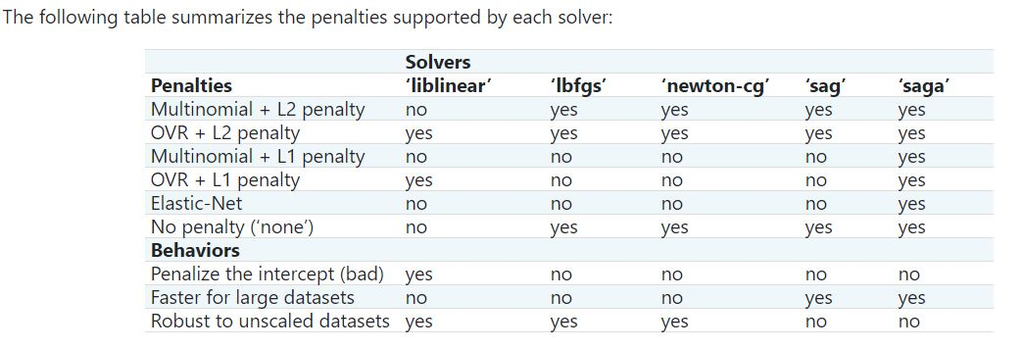

Penalties By Solver

```python
# general plotting function for many models
    from model_plotting import plot_tree, plot_knn_regressor, plot_lowess
    plot_tree(X, y, model, predict_proba = True)
```

### Python code for Linear Regression

```python
    from sklearn.linear_model import LinearRegression
    model = LinearRegression()
    model.fit(X,y)
    predicted = model.predict(z)
```

### Python code for Logistic Regression

```python
    from sklearn.linear_model import LogisticRegression
    model = LogisticRegression()
    model.fit(X,y)
    predicted = model.predict(z)
```

## Loess/Lowess

```python
    from statsmodels.nonparametric.smoothers_lowess import lowess
    n = 30 # number of samples
    k = 1  # k for kNN
    np.random.seed(0) # fix seed for reproducibility
    X = np.linspace(-1,1,n)+np.random.randn(n)*0.01
    X = X[:, None]
    y = (np.random.randn(n,1) + X*5).ravel()
    X = X.ravel()
    z = lowess(y, X, frac=5/n) # frac is like "k/n", larger vales lead to smoother curves
    plot_lowess(X, y, z)
```

## Generative vs discriminative models

- A visual metaphor from Jurafsky and Martin 2019: Imagine we are trying to distinguish dog images from cat images.
- A generative model would have the goal of understanding what dogs look like and what cats look like. You can ask a generative model to draw a dog. During predict, we ask which model fits the given image best.
- A discriminative model is only trying to learn to distinguish the classes. For instance, if all the dogs in the training data are wearing collars and cats aren’t, it would tell you that the difference between cats and dogs is that they do not wear collars.

## The fundamental Tradeoff, bias-variance Tradeoff

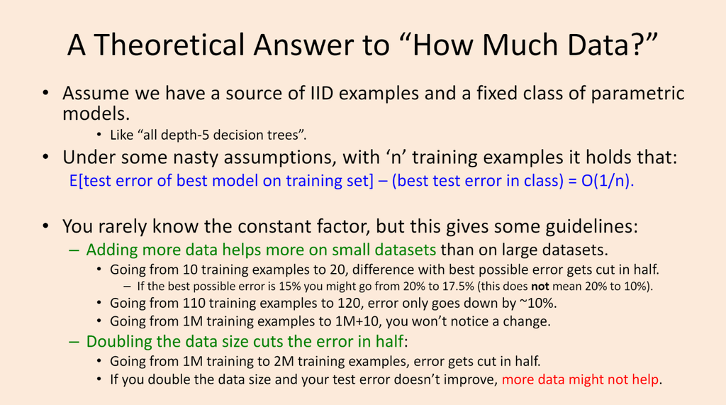

  [Why models with higher K have higher variance](https://stats.stackexchange.com/questions/61783/bias-and-variance-in-leave-one-out-vs-k-fold-cross-validation/357749#357749)

**Paraphrasing Yves Grandvalet the author of a 2004 paper on the topic I would summarize the intuitive argument as follows:**  
- If cross-validation were averaging independent estimates: then leave-one-out CV one should see relatively lower variance between models since we are only shifting one data point across folds and therefore the training sets between folds overlap substantially.  
- This is not true when training sets are highly correlated: Correlation may increase with K and this increase is responsible for the overall increase of variance in the second scenario. Intuitively, in that situation, leave-one-out CV may be blind to instabilities that exist, but may not be triggered by changing a single point in the training data, which makes it highly variable to the realization of the training set.  
- [Too much](http://www.jmlr.org/papers/volume5/grandvalet04a/grandvalet04a.pdf)

> My Intuition: Initially if you start increasing k then the variance should go down untill the data start to overlap majorly where the vairance start increasing if the data were independent it would continue to go down.

## Parametric vs Non-Parametric

- **Parametric**: A learning model that summarizes data with a set of parameters of fixed size (independent of the number of training examples) is called a parametric model. No matter how much data you throw at a parametric model, it won’t change its mind about how many parameters it needs.
  - Examples:
    - Logistic Regression
    - Linear Discriminant Analysis
    - Perceptron
    - Naive Bayes (I think as long as number of features remain the same its parametric but if vocabulary itself increases then it might be Non-Parametric)
    - Simple Neural Networks
  - Benefits:
    - Simpler: These methods are easier to understand and interpret results.
    - Speed: Parametric models are very fast to learn from data.
    - Less Data: They do not require as much training data and can work well even if the fit to the data is not perfect.
  - Limitations:
    - Constrained: By choosing a functional form these methods are highly constrained to the specified form.
    - Limited Complexity: The methods are more suited to simpler problems.
    - Poor Fit: In practice the methods are unlikely to match the underlying mapping function.
- **Non-Parametric**: Nonparametric methods are good when you have a lot of data and no prior knowledge, and when you don’t want to worry too much about choosing just the right features.
  - Examples:
    - k-Nearest Neighbors
    - Decision Trees like CART and C4.5 (Decision trees are kind of ambiguous)
    - Support Vector Machines
  - Benefits:
    - Flexibility: Capable of fitting a large number of functional forms.
    - Power: No assumptions (or weak assumptions) about the underlying function.
    - Performance: Can result in higher performance models for prediction.
  - Limitations:
    - More data: Require a lot more training data to estimate the mapping function.
    - Slower: A lot slower to train as they often have far more parameters to train.
    - Overfitting: More of a risk to overfit the training data and it is harder to explain why specific predictions are made.

## Typical Hyperparameter optimization framework

- [Visualising Cross Validation Behaviour in Scikit](https://scikit-learn.org/stable/auto_examples/model_selection/plot_cv_indices.html#sphx-glr-auto-examples-model-selection-plot-cv-indices-py)

```python
    from sklearn.model_selection import train_test_split, cross_val_score

    # split into training/validation and testing set
    X_train, X_test, y_train, y_test = train_test_split(X, y, test_size=0.2, random_state=123)

    # calculation loop
    k_dict = {'k':[], 'train_error':[], 'cv_error': []}
    for k in np.arange(1, 51):
        model = KNeighborsClassifier(n_neighbors=k).fit(X_train, y_train.to_numpy().ravel())
        k_dict['k'].append(k)
        k_dict['train_error'].append(1 - model.score(X_train, y_train.to_numpy().ravel())) # this is a little wrong...
        k_dict['cv_error'].append(1 - cross_val_score(model, X_train, y_train.to_numpy().ravel(), cv=5).mean())
    k_df = pd.DataFrame(k_dict)
    k_df = k_df.melt(id_vars='k', value_name='Error', var_name='Data') # melt datadframe to work with altair

    alt.Chart(k_df).mark_line().encode(x="k", y="Error", color='Data').properties(title='Accuracy vs Depths')


################
# Grid Search
################

  from sklearn import svm, datasets
  from sklearn.model_selection import GridSearchCV

  iris = datasets.load_iris()
  parameters = {'kernel':('linear', 'rbf'), 'C':[1, 10]}
  svc = svm.SVC()
  clf = GridSearchCV(svc, parameters)
  clf.fit(iris.data, iris.target)
  sorted(clf.cv_results_.keys())
```

## Feature normalization/standardization

```python
from sklearn.preprocessing import StandardScaler, MinMaxScaler
# Normalization
    # sets range to [0,1]
    X -= np.min(X,axis=0)
    X /= np.max(X,axis=0)
    MinMaxScaler()

    minmax = MinMaxScaler()
    minmax.fit(X_train2)
    X_train2_minmax = minmax.transform(X_train2)
    X_test2_minmax = minmax.transform(X_test2)
# standardization
    # sets sample mean to  0 , s.d. to  1
    X -= np.mean(X,axis=0)
    X /=  np.std(X,axis=0)
    StandardScaler()

    scaler = StandardScaler()
    scaler.fit(X_train2)
    X_train2_scaled = scaler.transform(X_train2)
    X_test2_scaled = scaler.transform(X_test2)
```

## Power transformers

- Apply a power transform featurewise to make data more Gaussian-like.
- Power transforms are a family of parametric, monotonic transformations that are applied to make data more Gaussian-like. This is useful for modeling issues related to heteroscedasticity (non-constant variance), or other situations where normality is desired.
- Currently, PowerTransformer supports the Box-Cox transform and the Yeo-Johnson transform. The optimal parameter for stabilizing variance and minimizing skewness is estimated through maximum likelihood.
  - Box-Cox requires input data to be strictly positive, while Yeo-Johnson supports both positive or negative data.
  - By default, zero-mean, unit-variance normalization is applied to the transformed data.

```python
    # PowerTransformer(copy=True, method='yeo-johnson', standardize=True)
    import numpy as np
    from sklearn.preprocessing import PowerTransformer
    pt = PowerTransformer()
    data = [[1, 2], [3, 2], [4, 5]]
    print(pt.fit(data)) # The optimal lambda parameter for minimizing skewness is estimated on each feature independently using maximum likelihood.
    print(pt.lambdas_)
    print(pt.transform(data)) # Apply the power transform to each feature using the fitted lambdas.
```

## Encoding categorical variables

### Label encoding

- Encode labels with value between 0 and n_classes-1.
- label encoding is only useful if there is ordinality in your data

```python
        from sklearn import preprocessing #Also: from sklearn.preprocessing import LabelEncoder #
        le = preprocessing.LabelEncoder()
        le.fit([1, 2, 2, 6])
        le.classes_
        le.transform([1, 1, 2, 6])
            # le.fit_transform([1, 1, 2, 6]) # this fits the data and then transform it
        le.inverse_transform([0, 0, 1, 2])
```

### One-hot encoding

- The features are encoded using a one-hot (aka ‘one-of-K’ or ‘dummy’) encoding scheme. This creates a binary column for each category and returns a sparse matrix or dense array.
- we have n categories in our column
- We create n new binary columns to represent those categories

```python
        from sklearn.preprocessing import OneHotEncoder
        df = pd.read_csv('data/depression_data.csv')
        X = df[['age', 'weight', 'treatment']]
        y = df['effect']

        ohe = OneHotEncoder(sparse=False, dtype=int)
        ohe.fit_transform(X[['treatment']])
        pd.concat((X, pd.DataFrame(ohe.fit_transform(X[['treatment']]), columns=ohe.categories_[0])), axis=1).head()

        ohe = OneHotEncoder(drop='first', sparse=False, dtype=int)
        X = pd.concat((X, pd.DataFrame(ohe.fit_transform(X[['treatment']]), columns=ohe.categories_[0][1:])), axis=1)
        # drop feature : ‘first’ or a list/array of shape (n_features,), default=None.
            # None : retain all features (the default).
            # ‘first’ : drop the first category in each feature. If only one category is present, the feature will be dropped entirely.
            # array : drop[i] is the category in feature X[:, i] that should be dropped.
```

## Preprocessing Both Numeric & Categorical

- preprocess both numeric features (e.g., scaling) and categorical features (e.g., OHE) at the same time ColumnTransformer()
  - his estimator allows different columns or column subsets of the input to be transformed separately and the features generated by each transformer will be concatenated to form a single feature space. This is useful for heterogeneous or columnar data, to combine several feature extraction mechanisms or transformations into a single transformer.

```python
        from sklearn.compose import ColumnTransformer
        from sklearn.preprocessing import MinMaxScaler, OneHotEncoder

        df = pd.read_csv('data/depression_data.csv')
        X = df[['age', 'weight', 'treatment']]
        y = df['effect']

        X_train, X_test, y_train, y_test = train_test_split(X, y, test_size=0.3, random_state=123)

        numeric_features = ['age', 'weight']
        categorical_features = ['treatment']

        preprocessor = ColumnTransformer(transformers=[
            ('minmax', MinMaxScaler(), numeric_features),
            ('ohe', OneHotEncoder(drop='first'), categorical_features)])

        # names the transformed variables
        # please note that `preprocessor.named_transformers_` doesn't work before fitting...once its fit this works
        col_names = (numeric_features + list(preprocessor.named_transformers_['ohe'].get_feature_names(categorical_features)))

        X_train = pd.DataFrame(preprocessor.fit_transform(X_train), index=X_train.index, columns=col_names)
        X_test = pd.DataFrame(preprocessor.transform(X_test), index=X_test.index, columns=X_train.columns)
```

## OVO vs OVR

- Important Link: [Wiki](https://en.wikipedia.org/wiki/Multiclass_classification), [Link1](https://datastoriesweb.wordpress.com/2017/06/11/classification-one-vs-rest-and-one-vs-one/), [Link2](https://www.quora.com/Whats-an-intuitive-explanation-of-one-versus-one-classification-for-support-vector-machines), [Link3](https://en.etsmtl.ca/ETS/media/ImagesETS/Labo/LIVIA/Publications/2006/MILGRAM_IWFHR_2006.pdf)

### OVO

- ovo is slower than ovr because it has to train more classifiers
- ovo is trained only on a subset of the data (2 classes at a time)
- local decision

### OVR

- in ovr each classifier is trained on the full dataset but if you have a large number of classes and if one of the classes is very skewed then that might pose a problem.
- There are ways to deal with class imbalance (e.g., assigning more weight to a rare class) but they don’t always work well.
- It may create class imbalance when we are training individual classifiers and if for some class we happen to have only a small number instances, the classifier won’t be able to learn much about that class.
- But remember that if this is a representative distribution of the test data, the class will be rare in the test data as well and you might not see a big difference in the test accuracy because poorly performing on rarely occurring class won’t matter much.
- global decision

## Ensemble Models

- The main advantage of ensembles of different classifiers is that it is unlikely that all classifiers will make the same mistake. In fact, as long as every error is made by a minority of the classifiers, you will achieve optimal classification! Unfortunately, the inductive biases of different learning algorithms are highly correlated. This means that different algorithms are prone to similar types of errors. In particular, ensembles tend to reduce the variance of classifiers. So if you have a classification algorithm that tends to be very sensitive to small changes in the training data, ensembles are likely to be useful.
- Note that the bootstrapped data sets will be similar. However, they will not be too similar. For example, if N is large then the number of examples that are not present in any particular bootstrapped sample is relatively large. The probability that the first training example is not selected once is (1 − 1/N). The probability that it is not selected at all is (1 − 1/N) N. As N → ∞, this tends to 1/e ≈ 0.3679. (Already for N = 1000 this is correct to four decimal points.) So only about 63% of the original training examples will be represented in any given bootstrapped set
- Since bagging tends to reduce variance, it provides an alternative approach to regularization.
- Key assumption: classifiers are independent in their predictions.
- If classifiers tend to make different kinds of errors ensembles tend to reduce the variance of classifiers.
- General methods to combine different classifiers to build an ensemble model
  - Majority voting (VotingClassifier)

```python
    classifiers = {
        "Decision tree"         : DecisionTreeClassifier(max_depth=5),
        "KNN"                   : KNeighborsClassifier(),
        "Naive Bayes"           : GaussianNB(),
        "Logistic Regression"   : LogisticRegression(),
        "SVM"                   : SVC(probability=True)
    }
    ensemble = VotingClassifier(classifiers.items(), voting="soft")
    ensemble.fit(X_train, y_train);
    print('Ensemble performance: \n')
    show_scores(ensemble, X_train, y_train, X_test, y_test)
```

- argument voting: If ‘hard’, uses predicted class labels for majority rule voting. Else if ‘soft’, predicts the class label based on the argmax of the sums of the predicted probabilities, which is recommended for an ensemble of well-calibrated classifiers.
- Bagging

## Pipelines

- Pipelines are a more elegant and organized way to do things

```python
numeric_features = ['age', 'fnlwgt', 'education.num',
                    'capital.gain', 'capital.loss',
                    'hours.per.week']

categorical_features = ['workclass', 'education', 'marital.status',
                        'occupation', 'relationship',
                        'race', 'sex', 'native.country']

numeric_transformer = Pipeline(steps=[
                                      ('imputer', SimpleImputer(strategy='median')),
                                      ('scaler', StandardScaler())
                                    ])


categorical_transformer = Pipeline(steps=[
                                          ('imputer', SimpleImputer(strategy='constant',
                                                                    fill_value='missing')),
                                          ('onehot', OneHotEncoder(handle_unknown='ignore'))
                                         ])

preprocessor = ColumnTransformer(
                                 transformers=[
                                    ('num', numeric_transformer, numeric_features),
                                    ('cat', categorical_transformer, categorical_features)
                                ])


# DummyClassifier is a classifier that makes predictions using simple rules. This classifier is useful as a simple baseline to compare with other (real) classifiers. Do not use it for real problems.

# Baseline model
from sklearn.dummy import DummyClassifier
print('Fitting baseline model: ')
dummy = DummyClassifier()

clf = Pipeline(steps=[('preprocessor', preprocessor),
                      ('classifier', dummy)])

t = time.time()
clf.fit(X_train, y_train)
tr_err, valid_err = get_scores(clf, X_train, y_train, X_valid, y_valid)
elapsed_time = time.time() - t



# Hyperparameter optimization with Logistic Regression
clf = Pipeline(steps=[('preprocessor', preprocessor),
                      ('classifier', LogisticRegression())])

param_grid = {
    'preprocessor__num__imputer__strategy': ['mean', 'median'],
    'classifier__C': [0.1, 1.0, 10, 100],
}

grid_search = GridSearchCV(clf, param_grid, cv=10)
grid_search.fit(X_trainvalid, y_trainvalid)

print(("best logistic regression from grid search: %.3f"
       % grid_search.score(X_valid, y_valid)))
```

# Algorithms

## Boosting

- Important Links: [source book chapter](http://ciml.info/dl/v0_99/ciml-v0_99-ch13.pdf), [Not reading now](https://mitpress.mit.edu/sites/default/files/titles/content/boosting_foundations_algorithms/chapter001.html), [Bagging vs Boosting](https://quantdare.com/what-is-the-difference-between-bagging-and-boosting/)
- High-level Summary
  - AdaBoost
  - Gradient boosting
    - Gradient boosting is a particular interpretation of boosting that allows generalizing it.
    - Gradient boosting interprets predictions as parameters, then does gradient descent w.r.t. predictions. Each “iteration” adds a base model (“learner”) to the ensemble.
  - XGBoost (eXtreme Gradient Boosting)
    - XGBoost is a particular industrial-strength implementation of gradient boosted trees.
  - Light GBM
    - Another tree-based gradient boosting framework
    - Great for large-scale datasets
    - Lower memory because of depth-first search like growth
- Boosting is the process of taking a crummy learning algorithm (technically called a weak learner) and turning it into a great learning algorithm (technically, a strong learner).
- Boosting is more of a “framework” than an algorithm.
- The particular boosting algorithm discussed here is AdaBoost, short for “adaptive boosting algorithm.” AdaBoost is famous because it was one of the first practical boosting algorithms: it runs in polynomial time and does not require you to define a large number of hyperparameters. It gets its name from the latter benefit: it automatically adapts to the data that you give it.
- One of the major attractions of boosting is that it is perhaps easy to design computationally efficient weak learners. A very popular type of weak learner is a shallow decision tree: a decision tree with a small depth limit.

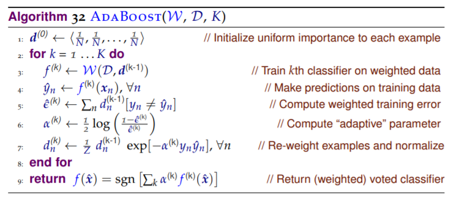

Image of algo

- **Strong learning algorithm**- a strong learning algorithm L as follows. When given a desired error rate e, a failure probability δ and access to “enough” labeled examples from some distribution D, then, with high probability (at least 1 − δ), L learns a classifier f that has error at most e
- **weak learning algorithm**- a weak learning algorithm W that only has to achieve an error rate of 49%, rather than some arbitrary user-defined parameter e. (49% is arbitrary: anything strictly less than 50% would be fine.

> **Boosting analogy**(kind of what apoorv was saying)- The intuition behind AdaBoost is like studying for an exam by using a past exam. You take the past exam and grade yourself. The questions that you got right, you pay less attention to. Those that you got wrong, you study more. Then you take the exam again and repeat this process. You continually down-weight the importance of questions you routinely answer correctly and up-weight the importance of questions you routinely answer incorrectly. After going over the exam multiple times, you hope to have mastered everything.
- adaptive parameter α- The (weighted) error rate of $f^{(k)}$ is used to determine the adaptive parameter α, which controls how “important” $f^{(k)}$ is. As long as the weak learner does, indeed, achieve < 50% error, then α will be greater than zero. As the error drops to zero, α grows without bound.

### Understanding what alpha does-

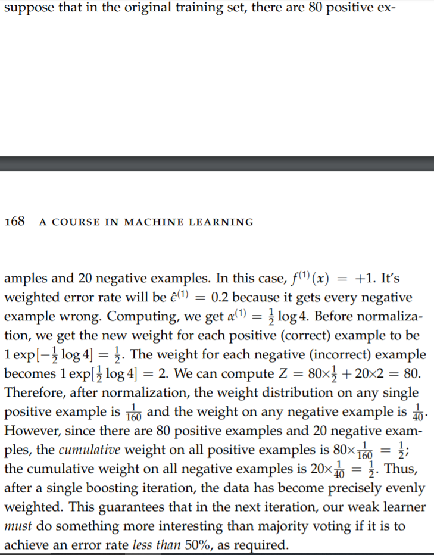

understanding what alpha does

## Boosting decision stumps-

[figure not shown]

[figure not shown]

- In fact, a very popular weak learner is a decision decision stump: a decision tree that can only ask one question. Boosting algorithm takes weak learners like decisionstump and convert it into a linear classifier form (the math is pretty simple actually).
- By concentrating on decision stumps, all weak functions must have the form
  $$f(x) = s(2x_d − 1)$$
  , where s ∈ {±1} and d indexes some feature
- When working with decision stumps, AdaBoost actually provides an algorithm for learning linear classifiers! In fact, this connection has recently been strengthened: you can show that AdaBoost provides an algorithm for optimizing exponential loss.
- You can notice that this is nothing but a two-layer neural network, with K-many hidden units! Of course it’s not a classifically trained neural network (once you learn w(k) you never go back and update it), but the structure is identical.

## Random forests General ideal

- fit a diverse set of classifiers by injecting randomness in the classifier construction
  - Randomness in Data:
    - Build each tree on a bootstrap sample (i.e., a sample drawn with replacement from the training set)
  - Randomness in Features:
    - Consider a random subset of features at each split (RandomForestClassifier)
    - Consider a random subset of features at each split and random threshold (ExtraTreesClassifier)
- At each node of the tree:
  - Randomly select a subset of features out of all features (independently for each node).
  - Find the best split on the selected features.
  - Grow the trees to maximum depth.
- predict by taking the average of predictions given by individual classifiers
- Random forests are usually more accurate compared to decision trees, in fact they are usually one of the best performing off-the-shelf classifiers.
- error rate depends upon the following:
  - The correlation between any two trees in the forest. Higher the correlation higher the error rate.
  - The error rate of each individual tree in the forest. Lowering the error rate of the individual trees decreases the forest error rate.
- Can easily parallelize training because all trees are independent of each other
- Random forests are less likely to overfit
- Like decision trees, but unlike most ML models, the running time of calling predict for a random forest is independent of 𝑑.
- Increasing the hyperparameter max_features (the number of features to consider for a split) makes the model more complex and moves the fundamental tradeoff toward lower training error.
  - Intuitively, higher value for max_features means we have higher number of features to be considered at each split, which means that the individual trees are more similar to what a decision tree algorithm would give you. But the ensemble would be less diverse and hence less effective now when it comes to generalization. (Recall that we also have randomness from bootstrap resampling and so it’s still likely to be better than a decision tree.)
- Increasing the hyperparameter n_estimators (the number of trees) makes the model more complex and moves the fundamental tradeoff toward lower training error.
  - This is False. This is kind of ambiguous but I would say false here. In random forests we get rid of the variance by averaging, and larger the number of trees the better. But large number of trees means more computational time. According to [Breiman](https://www.stat.berkeley.edu/~breiman/randomforest2001.pdf), increasing `n_estimators` in a random forest ensemble should not increase generalization error and should not lead to overfitting. (That said, in practice, people have observed that increasing n_estimators can lead to overfitting in some cases.)
- One of the most computationally expensive aspects of ensembles of decision trees is training the decision trees. This is very fast for decision stumps, but for deeper trees it can be prohibitively expensive. The expensive part is choosing the tree structure. Once the tree structure is chosen, it is very cheap to fill in the leaves (i.e., the predictions of the trees) using the training data.
- An efficient and surprisingly effective alternative is to use trees with fixed structures and random features. Collections of trees are called forests, and so classifiers built like this are called random forests
- It takes three arguments: the data, a desired depth of the decision trees, and a number K of total decision trees to build. The algorithm generates each of the K trees independently, which makes it very easy to parallelize. For each trees, it constructs a full binary tree of depth depth. The features used at the branches of this tree are selected randomly, typically with replacement, meaning that the same feature can appear multiple times, even in one branch. The leaves of this tree, where predictions are made, are filled in based on the training data. This last step is the only point at which the training data is used. The resulting classifier is then just a voting of the Kmany random trees.

### Python code for Random Forest, [Wiki](https://en.wikipedia.org/wiki/Random_forest)

```python
  from sklearn.ensemble import RandomForestClassifier
  model = RandomForestClassifier()
  model.fit(X, y)
  predicted = model.predict(z)
```

## SVMs: General idea

[SVM tutorial](https://www.microsoft.com/en-us/research/publication/a-tutorial-on-support-vector-machines-for-pattern-recognition/?from=http%3A%2F%2Fresearch.microsoft.com%2Fpubs%2F67119%2Fsvmtutorial.pdf)

- Choose the hyperplane which is furthest away from the closest training points.
- In other words, choose the hyperplane which has the largest margin, where margin is the distance from the boundary to the nearest point(s).
- Intuitively, more margin is good because it leaves more “room” before we make an error.
- Main idea: the decision boundary only depends on the support vectors.
- SVMs not only work with linearly-separable data. We can use the “kernel” trick to deal with non linearly separable surfaces
  - The general idea is mapping the non-linearly separable data into a higher dimensional space where you can find a separating hyperplane.
- Note that SVC multiclass mode is implemented using one-vs-one scheme whereas LinearSVC uses one-vs-rest scheme.
  - That said, we can use the OneVsRestClassifier wrapper to implement one-vs-rest with SVC.

### Support vectors

- Each training example either is or isn’t a “support vector”.
- This gets decided during fit.
- It does not apply to test examples.
- If we delete all non-support vector the decision boundary won’t change
- If we delete a support vector the decision boundary gets changed

### Key Hyperparameters of rbf SVM are

- `gamma`
  - Larger gamma(more complex): more rapid fluctuations in the decision surface (can change from red to blue in a short distance).
  - Smaller gamma smoother fluctuations.
- `C`
  - Large C, more complex
  - You can think of larger C as insistence on getting low training error; smaller C forgives more errors.
  - Larger C also leads to more confident predictions.

### [The math of SVM explained well](https://stackoverflow.com/questions/9480605/what-is-the-relation-between-the-number-of-support-vectors-and-training-data-and)

- Support Vector Machines are an optimization problem. They are attempting to find a hyperplane that divides the two classes with the largest margin. The support vectors are the points which fall within this margin. It’s easiest to understand if you build it up from simple to more complex.
- Hard Margin Linear SVM
  - In an a training set where the data is linearly separable, and you are using a hard margin (no slack allowed), the support vectors are the points which lie along the supporting hyperplanes (the hyperplanes parallel to the dividing hyperplane at the edges of the margin)

### Python code for Support Vector Machine

```python
    from sklearn.svm import SVC
    model = SVC(kernel=’rbf’)
    model.fit(X,y)
    predicted = model.predict(z)
```

## Scikit learning- KNN:

- Source: [Link1](https://scikit-learn.org/stable/modules/neighbors.html), [Link2](https://github.ubc.ca/MDS-2019-20/DSCI_571_sup-learn-1_students/blob/master/lectures/lecture3.ipynb)
- **Questions**:
  - Dont understand how scikit learn switches from tree based approach to brute force using the leaf size parameter of the tree
    - I think its kind of a backend optimization using the leafsize parameter
  - Why cant KNN just predict by checking the shading color for a test example isntead of computing all those distances? **Tom’s Answer**
    - Firstly, if you look at the code I wrote, the “shading colour” is generated by creating an extremely fine mesh of points and then predicting every single one of them. That is computationally very expensive (but great for visualization!). It’s not like kNN just output a nice boundary that we could use.
    - But, you could use this method to generate “decision boundaries” for yourself if you wanted to. It’s just the to do this you have to make hundreds, thousands or even millions of predictions depending on your data size and number of features. So it doesn’t seem worth it. Also note that if you obtained more data, or more features in future, or changed your hyperparameters, you would then have to recalculate these decision boundaries!
- K-d trees & more on Knn: [Link1](https://machine-learning-course.readthedocs.io/en/latest/content/supervised/knn.html), [Link2](https://github.ubc.ca/MDS-2019-20/DSCI_512_alg-data-struct_students/blob/master/lectures/lecture4.ipynb)

### Classification:

- Neighbors-based classification is a type of instance-based learning or non-generalizing learning: it does not attempt to construct a general internal model, but simply stores instances of the training data.
- scikit-learn implements two different nearest neighbors classifiers:
  - `KNeighborsClassifier` (most commonly used) implements learning based on the `k` nearest neighbors of each query point, where `k` is an integer value specified by the user.
  - `RadiusNeighborsClassifier` implements learning based on the number of neighbors within a fixed radius `r` of each training point, where `r` is a floating-point value specified by the user.
    - In cases where the data is not uniformly sampled, radius-based neighbors classification in RadiusNeighborsClassifier can be a better choice.
- In general a larger k suppresses the effects of noise, but makes the classification boundaries less distinct.
- For high-dimensional parameter spaces, this method becomes less effective due to the so-called “curse of dimensionality”.
- `weights`
  - `weights = 'uniform'`, assigns uniform weights to each neighbor.
  - `weights = 'distance'` assigns weights proportional to the inverse of the distance from the query point.
  - Alternatively, a user-defined function of the distance can be supplied to compute the weights.

### Regression:

- The label assigned to a query point is computed based on the mean of the labels of its nearest neighbors.
- scikit-learn implements two different neighbors regressors:
  - `KNeighborsRegressor` implements learning based on the k nearest neighbors of each query point, where k is an integer value specified by the user.
  - `RadiusNeighborsRegressor` implements learning based on the neighbors within a fixed radius r of the query point, where r is a floating-point value specified by the user.
- `weights` follow a similar approach as in classification
- The most naive neighbor search implementation involves the brute-force computation (`algorithm = 'brute'`) of distances between all pairs of points in the dataset: for N samples in D dimensions, this approach scales as $O(D*N^2)$.
- To address the computational inefficiencies of the brute-force approach, a variety of tree-based data structures have been invented like KD-Tree(`algorithm = 'kd_tree'`). In this way, the computational cost of a nearest neighbors search can be reduced to $O(D*N*log(N))$ or better.
- The construction of a KD tree is very fast: because partitioning is performed only along the data axes, no D-dimensional distances need to be computed. Once constructed, the nearest neighbor of a query point can be determined with only $O(log(N))$ distance computations.
  - Though the KD tree approach is very fast for low-dimensional (D<20) neighbors searches, it becomes inefficient as D grows very large: this is one manifestation of the so-called “curse of dimensionality”.
- Where KD trees partition data along Cartesian axes, ball trees (`algorithm = 'ball_tree'`) partition data in a series of nesting hyper-spheres. This makes tree construction more costly than that of the KD tree, but results in a data structure which can be very efficient on highly structured data, even in very high dimensions.
- A ball tree (complexity: $O(D*log(N))$) recursively divides the data into nodes defined by a centroid C and radius r, such that each point in the node lies within the hyper-sphere defined by r and C. The number of candidate points for a neighbor search is reduced through use of the triangle inequality: |x+y| <= |x| + |y| (vector mathmatics used here. x+y is a vector sum of 2 vectors x & y)
  - A single distance calculation between a test point and the centroid is sufficient to determine a lower and upper bound on the distance to all points within the node.
- Because of the spherical geometry of the ball tree nodes, it can out-perform a KD-tree in high dimensions, though the actual performance is highly dependent on the structure of the training data.

### Choice of algorithm is dependent on following things:

- number of samples N (i.e. n_samples) and dimensionality D (i.e. n_features).
  - KD tree query can be very efficient for D <20. If you add a new dimension to a data then the amount of data needed to make the data similarly sparseed will be exponential because you are adding a whole new dimension.
  - For N less than 30, brute force algorithms can be more efficient than a tree-based approach.
  - Tree based algo uses leaf size parameter: this controls the number of samples at which a query switches to brute-force. This allows both algorithms to approach the efficiency of a brute-force computation for small N.
- data structure: intrinsic dimensionality of the data and/or sparsity of the data.
  - This is related to dimensionality reduction, i.e. identifying Intrinsic dimensionality d<=D
- number of neighbors k requested for a query point.
  - Brute force is unaffected by k.
  - Ball tree and KD tree query time will become slower as k increases because a larger k leads to the necessity to search a larger portion of the parameter space.
  - As k becomes large compared to N, the ability to prune branches in a tree-based query is reduced. In this situation, Brute force queries can be more efficient.
  - A higher k value will ignore outliers to the data and a lower will give more weight to them. If the k value is too high it will not be able to classify the data, so k needs to be relatively small.
- number of query points.
  - Amortization- doing a lot of work up front to save time later. Building a tree that takes long time and then using it for querying(takes very less time) a lot of samples is better than brute force.
  - The cost of ball-tree & KD Tree construction becomes negligible when amortized over many queries.

```python
from sklearn.neighbors import KNeighborsClassifier, KNeighborsRegressor

X = pd.DataFrame({'feature1': [5, 4, 2, 10, 9, 9],
                  'feature2': [2, 3, 2, 10, -1, 9]})
y = pd.DataFrame({'target': ['0', '0', '1', '1', '1', '2']})

knn = KNeighborsClassifier(n_neighbors=3).fit(X, y.to_numpy().ravel())
plot_tree(X, y, knn)
knn.predict(np.atleast_2d([0, 0]))

y = pd.DataFrame([0, 0, 1, 1, 1, 2])
knn = KNeighborsRegressor(n_neighbors=3).fit(X, y)
knn.predict(np.atleast_2d([0, 0]))

1 - knn.score(X, y)
```

## Naive Bayes

[Scikit learn Naive bayes short documentation](https://scikit-learn.org/stable/modules/naive_bayes.html)

- [“bag-of-words” representation refers to turning text into numerical feature vectors](https://scikit-learn.org/stable/modules/feature_extraction.html#text-feature-extraction)
  - We call vectorization the general process of turning a collection of text documents into numerical feature vectors This specific strategy (tokenization, counting and normalization) is called the Bag of Words or “Bag of n-grams” representation. Documents are described by word occurrences while completely ignoring the relative position information of the words in the document.
    - tokenizing strings and giving an integer id for each possible token, for instance by using white-spaces and punctuation as token separators.
    - counting the occurrences of tokens in each document.
    - normalizing and weighting with diminishing importance tokens that occur in the majority of samples / documents.
- `CountVectorizer()`
  - Convert a collection of text documents to a matrix of token counts
  - This implementation produces a sparse representation of the counts using scipy.sparse.csr_matrix.
  - If you do not provide an a-priori dictionary and you do not use an analyzer that does some kind of feature selection then the number of features will be equal to the vocabulary size found by analyzing the data.
- `MultinomialNB(alpha=1.0, fit_prior=True, class_prior=None)`
  - alpha : float, optional (default=1.0)
  - Additive (Laplace/Lidstone) smoothing parameter (0 for no smoothing).
    - How does the choice of alpha influence our results?
      - High 𝛼 “dilutes the data” and gives an underfit model (one that tends towards predicting the priors)
      - Low 𝛼 “empowers the data” and gives an overfit model (one that tends towards predicting the product of the conditional probabilities)
  - fit_prior : boolean, optional (default=True)
  - Whether to learn class prior probabilities or not. If false, a uniform prior will be used.
  - class_prior : array-like, size (n_classes,), optional (default=None)
  - Prior probabilities of the classes. If specified the priors are not adjusted according to the data.
- `partial_fit(X, y, classes=None, sample_weight=None)`
  - Incremental fit on a batch of samples.
  - This method is expected to be called several times consecutively on different chunks of a dataset so as to implement out-of-core or online learning.
  - This is especially useful when the whole dataset is too big to fit in memory at once.
  - This method has some performance overhead hence it is better to call partial_fit on chunks of data that are as large as possible (as long as fitting in the memory budget) to hide the overhead.
    - More on [`out of core classification`](https://scikit-learn.org/stable/auto_examples/applications/plot_out_of_core_classification.html#sphx-glr-auto-examples-applications-plot-out-of-core-classification-py)
- `BernoulliNB`
  - this model doesn’t care about word counts, it just cares about whether a word exists or not in a document (binary), and how many documents there are.
- `Gaussian`
  - Assume each feature is normally distributed

### Transform a count matrix to a normalized tf or tf-idf representation

- Tf means term-frequency while tf-idf means term-frequency times inverse document-frequency. This is a common term weighting scheme in information retrieval, that has also found good use in document classification.
- The goal of using tf-idf instead of the raw frequencies of occurrence of a token in a given document is to scale down the impact of tokens that occur very frequently in a given corpus and that are hence empirically less informative than features that occur in a small fraction of the training corpus.
- The formula that is used to compute the tf-idf for a term t of a document d in a document set is tf-idf(t, d) = tf(t, d) * idf(t), and the idf is computed as idf(t) = log [ n / df(t) ] + 1 (if smooth_idf=False), where n is the total number of documents in the document set and df(t) is the document frequency of t; the document frequency is the number of documents in the document set that contain the term t. The effect of adding “1” to the idf in the equation above is that terms with zero idf, i.e., terms that occur in all documents in a training set, will not be entirely ignored. (Note that the idf formula above differs from the standard textbook notation that defines the idf as idf(t) = log [ n / (df(t) + 1) ]).
- If smooth_idf=True (the default), the constant “1” is added to the numerator and denominator of the idf as if an extra document was seen containing every term in the collection exactly once, which prevents zero divisions: idf(d, t) = log [ (1 + n) / (1 + df(d, t)) ] + 1.
  - More on https://scikit-learn.org/stable/modules/generated/sklearn.feature_extraction.text.TfidfTransformer.html#sklearn.feature_extraction.text.TfidfTransformer

```python
import pandas as pd
import numpy as np


from sklearn.feature_extraction.text import CountVectorizer, TfidfVectorizer
cv = CountVectorizer()
X = cv.fit_transform(df['sentence']) # CSR sparse matrix
bow = pd.DataFrame(X.toarray(), columns=sorted(cv.vocabulary_), index=df['sentence']) # works only on small data set
bow

# Multinomial Naive Bayes from lab2
from sklearn.naive_bayes import MultinomialNB
cv = CountVectorizer()
X_train_counts = cv.fit_transform(X_train['review'])
X_test_counts = cv.transform(X_test['review'])

nb = MultinomialNB()
nb.fit(X_train_counts, np.squeeze(y_train))

print("The accuracy score of the Multinomial NB model using CountVectorizer on train data is:", nb.score(X_train_counts, np.squeeze(y_train)), "and on test data is: ", nb.score(X_test_counts, np.squeeze(y_test)))

print(nb.classes_)
nb.predict_proba(X_test_counts)
nb.predict(X_test_counts)


# Using tf-idf representation
cv2 = TfidfVectorizer()
X_train_tfidf = cv2.fit_transform(X_train['review'])
X_test_tfidf = cv2.transform(X_test['review'])

nb2 = MultinomialNB()
nb2.fit(X_train_tfidf, np.squeeze(y_train))

print("The accuracy score of the Multinomial NB model using CountVectorizer on train data is:", nb2.score(X_train_tfidf, np.squeeze(y_train)), "and on test data is: ", nb2.score(X_test_tfidf, np.squeeze(y_test)))
# Multinomial Naive Bayes from lab2

# works the same way
nb = BernoulliNB() # Bernouli
nb = GaussianNB() # Gaussian


##### Scikit
corpus = [
    'This is the first document.',
    'This document is the second document.',
    'And this is the third one.',
    'Is this the first document?',
]
vectorizer = CountVectorizer()
X = vectorizer.fit_transform(corpus)
print(vectorizer.get_feature_names())
##### Scikit
```

## Gradient Boosting

**Great source: [souce](http://www.chengli.io/tutorials/gradient_boosting.pdf)**

- `Gradient boosting = Gradient Descent + Boosting`
- Gradient Boosting is an extension of adaboost to handle a variety of loss functions
- Difficulty in using Gradient Boosting for Different Problems: `regression ===> classification ===> ranking`
- You are given $(x1, y1),(x2, y2), ...,(xn, yn)$, and the task is to fit a model $F(x)$ to minimize square loss. Suppose your friend wants to help you and gives you a model F. You check his model and find the model is good but not perfect. There are some mistakes: $F(x1) = 0.8$, while $y1 = 0.9$, and $F(x2) = 1.4$ while $y2 = 1.3$… How can you improve this model?
- You can add an additional model (regression tree) h to F, so the new prediction will be $F(x) + h(x)$.
- Or, equivalently,

```
h(x1) = y1 − F(x1)
h(x2) = y2 − F(x2)
...
h(xn) = yn − F(xn)
```

- where h(x) are called residuals and you just fit a regression tree h to data $(x1, y1 − F(x1)),(x2, y2 − F(x2)), ...,(xn, yn − F(xn))$
- If the new model F + h is still not satisfactory, we can add another regression tree…

### Gradient Descent

- You have a loss function J which is sometimes sum of squared errors. You determine the slope of loss function and using that information you move in the direction where the error decreases that is why you multiply negative gradient with some value like $\rho$ which can change value depending on the slope or remain constant.
- Relation between Gradient Descent and Gradient Boosting-

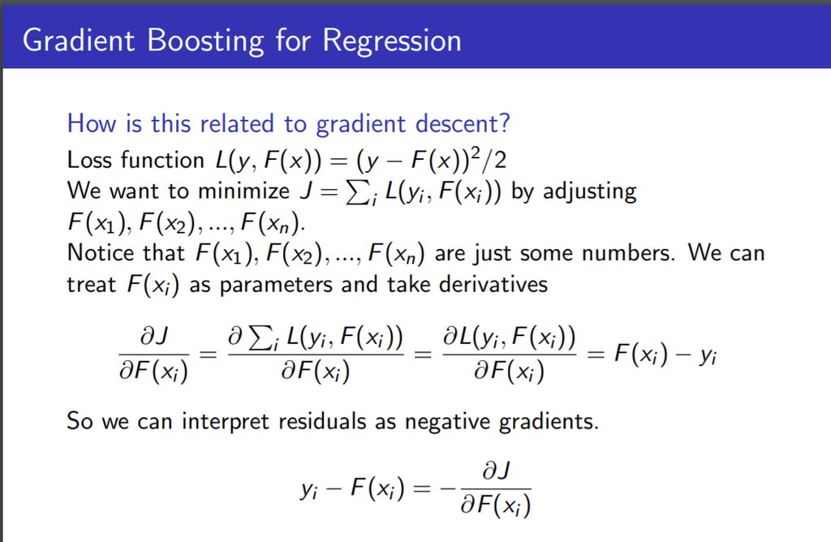

- For regression with square loss,
  - residual ⇔ negative gradient
  - fit h to residual ⇔ fit h to negative gradient
  - update F based on residual ⇔ update F based on negative gradient

```
    start with an initial model, say, F(x) = mean of all yi
    iterate until converge:
        calculate negative gradients −g(xi)
        fit a regression tree h to negative gradients −g(xi)
        F := F + ρh, where ρ = 1
```

**So we are actually updating our model using gradient descent!**

- The benefit of formulating this algorithm using gradients is that it allows us to consider other loss functions and derive the corresponding algorithms in the same way.
- Squared loss function not robust to outliers but easy to deal with mathematically. Outliers are heavily punished because the error is squared.
  - absolute loss & huber loss are more robust to outliers

```python
from sklearn.ensemble import GradientBoostingClassifier
clf = GradientBoostingClassifier(n_estimators=100, learning_rate=1.0,
     max_depth=1, random_state=0).fit(X_train, y_train)
```

## Naive Bayes vs. Logistic regression

- Both are probabilistic classifiers but Naive Bayes is “generative” and Logistic regression is “discriminative”
- Naive Bayes is a generative model because it’s modeling the joint distribution over the features $x$ and labels $y$.
- Logistic regression it directly models the probability $p(y|x)$

## Choosing a classifier: Logistic regression vs. Naive Bayes

- Naive Bayes has overly strong conditional independence assumptions. So not great when features are correlated.
  - If two features are strongly correlated, Naive Bayes will overestimating the evidence of that feature.
- Logistic regression is much more robust to correlated features
  - If two features are correlated, regression will assign part of the weight to one and part to another.
- For smaller datasets Naive Bayes is a good choice. Logistic regression generally works better on larger datasets and is a common default.

## Why people use linear classifiers?

- Logistic regression is used EVERYWHERE!
- Fast training and testing.
  - Training on huge datasets.
  - Testing is just computing $w^Tx_i$.
- Weights $w_j$ are easy to understand.
  - It’s how much $x_j$ changes the prediction and in what direction.
- Are somewhat related to neural networks (can be thought of as a 1-layer neural network)
- When I carry out research, logistic regression is the first model I try as a baseline.
- By default LogisticRegression uses one-vs-rest strategy to deal with multi-class